# Projeto Integrador: Predizendo o número de inscritos em canais do Youtube

Luiz Gabriel de Souza

29/04/2021

### 1 - Carregando a base de dados e os pacotes necessários:

```r
library(ggplot2)
library(ggthemes)
library(tidyr)
suppressMessages(library(dplyr))

df <- read.csv("youtube.txt", sep = "")
head(df)
```

```
##   DIAS VIEWS INSCRITOS         CANAL
## 1    1  5200        66 inventonahora
## 2    2  4600        89 inventonahora
## 3    3  5200       103 inventonahora
## 4    4  4400        87 inventonahora
## 5    5  5100       102 inventonahora
## 6    6  6200        93 inventonahora
```

```r
str(df)
```

```
## 'data.frame':    1457 obs. of  4 variables:
##  $ DIAS     : int  1 2 3 4 5 6 7 8 9 10 ...
##  $ VIEWS    : int  5200 4600 5200 4400 5100 6200 4800 4500 3700 3700 ...
##  $ INSCRITOS: int  66 89 103 87 102 93 61 74 53 70 ...
##  $ CANAL    : chr  "inventonahora" "inventonahora" "inventonahora" "inventonahora" ...
```

### 2 - Separando os dados por canal:

```r
channels <- unique(df$CANAL)
df.1 <- df %>% filter(CANAL == channels[1])
df.2 <- df %>% filter(CANAL == channels[2])
head(df.1)
```

```
##   DIAS VIEWS INSCRITOS         CANAL
## 1    1  5200        66 inventonahora
## 2    2  4600        89 inventonahora
## 3    3  5200       103 inventonahora
## 4    4  4400        87 inventonahora
## 5    5  5100       102 inventonahora
## 6    6  6200        93 inventonahora
```

```r
head(df.2)
```

```
##      DIAS VIEWS INSCRITOS     CANAL
## 1545    1  5674       315 vocesabia
## 1546    2  3255       331 vocesabia
## 1547    3   613        42 vocesabia
## 1548    4   580        21 vocesabia
## 1549    5   379         7 vocesabia
## 1550    6   303         6 vocesabia
```

### 3 - Calculando o número acumulado de inscritos para cada canal:

```r
df.1$cum.inscritos <- cumsum(df.1$INSCRITOS)/100000
head(df.1)
```

```
##   DIAS VIEWS INSCRITOS         CANAL cum.inscritos
## 1    1  5200        66 inventonahora       0.00066
## 2    2  4600        89 inventonahora       0.00155
## 3    3  5200       103 inventonahora       0.00258
## 4    4  4400        87 inventonahora       0.00345
## 5    5  5100       102 inventonahora       0.00447
## 6    6  6200        93 inventonahora       0.00540
```

```r
df.2$cum.inscritos <- cumsum(df.2$INSCRITOS)/100000
head(df.2)
```

```
##      DIAS VIEWS INSCRITOS     CANAL cum.inscritos
## 1545    1  5674       315 vocesabia       0.00315
## 1546    2  3255       331 vocesabia       0.00646
## 1547    3   613        42 vocesabia       0.00688
## 1548    4   580        21 vocesabia       0.00709
## 1549    5   379         7 vocesabia       0.00716
## 1550    6   303         6 vocesabia       0.00722
```

### 4 - Criando as funções necessárias:

#### 4.1 - Modelo logístico $y = \dfrac{L}{1 + e^{-\beta(x - \beta_0)}}$, onde:

- par[1] = $\beta$;
- par[2] = $\beta_0$;
- par[3] = $L$

```r
f.log <- function(par, dias) {
  return(par[3] / (1 + exp(-par[1]*(dias - par[2]))))
}
```

#### 4.2 - Função Perda Quadrática $\sum_{i=1}^n (y_i - μ)^2$:

```r
p.quad <- function(y, mu) {
  return(sum((y - mu)^2))
}
```

#### 4.3 - Função objetivo:

```r
f.log.ols <- function(par, y, dias) {
  mu <- f.log(par, dias)
  SQ <- p.quad(y, mu)
  return(SQ)
}
```

### 5 - Canal 1 - Invento na Hora:

#### 5.1 - Sumarizando os dados:

```r
summary(df.1)
```

```
##       DIAS           VIEWS          INSCRITOS          CANAL
##  Min.   :  1.0   Min.   :  3700   Min.   :   33.0   Length:850
##  1st Qu.:213.2   1st Qu.: 31000   1st Qu.:  548.2   Class :character
##  Median :425.5   Median :102500   Median : 2489.0   Mode  :character
##  Mean   :425.5   Mean   :109450   Mean   : 2494.5
##  3rd Qu.:637.8   3rd Qu.:158000   3rd Qu.: 3839.8
##  Max.   :850.0   Max.   :697000   Max.   :14611.0
##  cum.inscritos
##  Min.   : 0.00066
##  1st Qu.: 0.67368
##  Median : 4.53974
##  Mean   : 6.82862
##  3rd Qu.:11.94170
##  Max.   :21.20289
```

#### 5.2 - Gráfico do número acumulado de inscritos por dia:

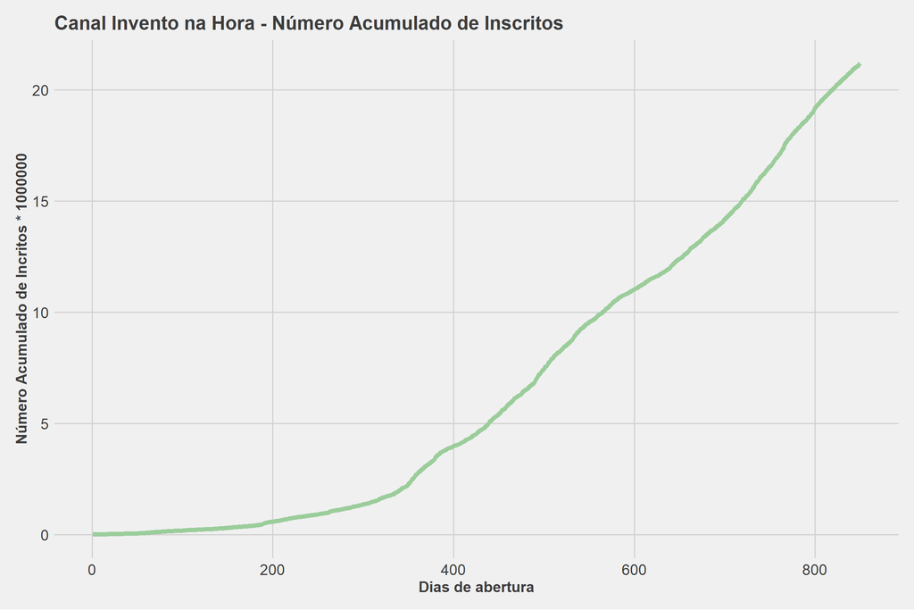

```r
title.c1 = "Canal Invento na Hora"

cum.plot <- function(df, x, y, title) {
  plot <- ggplot(df, aes(x = x)) +
    geom_line(aes(y = y), colour = "darkseagreen3", size = 2) +
    labs(x = "Dias de abertura", y = "Número Acumulado de Incritos * 1000000", title = title) +
    theme_fivethirtyeight() +
    theme(axis.text = element_text(size = 14),
          axis.title = element_text(size = 14, face = "bold"),
          plot.title = element_text(size = 18))
  return(plot)
}
cum.plot(df = df.1, x = df.1$DIAS, y = df.1$cum.inscritos, title = paste(title.c1, "Número Acumulado de Inscritos", sep = " - "))
```

#### 5.3 - Gráfico do número de inscritos por dia:

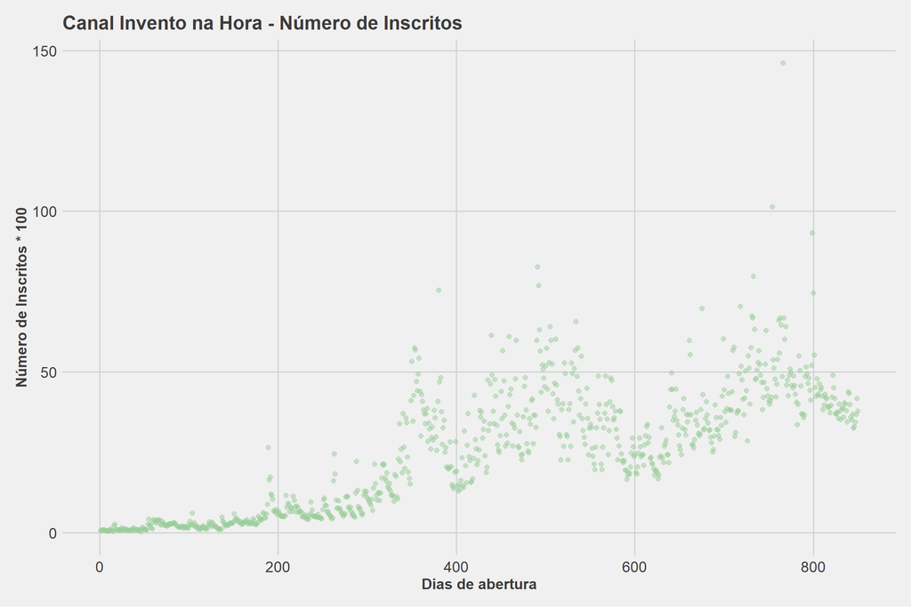

```r
qty.plot <- function(df, x, y, title) {
  ggplot(df, aes(x = x)) +
    geom_point(aes(y = y/100), color = "darkseagreen3", alpha = 0.5, size = 2) +
    labs(x = "Dias de abertura", y = "Número de Inscritos * 100", title = title) +
    theme_fivethirtyeight() +
    theme(axis.text = element_text(size = 14),
          axis.title = element_text(size = 14, face = "bold"),
          plot.title = element_text(size = 18))
}
qty.plot(df = df.1, x = df.1$DIAS, y = df.1$INSCRITOS, title = paste(title.c1, "Número de Inscritos", sep = " - "))
```

#### 5.4 - Preparando um data frame com o número total de dias que será alimentado com os valores preditos:

```r
pred.df <- function(df, days) {
  df.out <- data.frame(
    DIAS = c(df$DIAS, (max(df$DIAS)+1):(max(df$DIAS)+days)),
    VIEWS = c(df$VIEWS, rep(NA, days)),
    INSCRITOS = c(df$INSCRITOS, rep(NA, days)),
    CANAL = channels[1],
    cum.inscritos = c(df$cum.inscritos, rep(NA, days))
  )
}

df.1.pred <- pred.df(df.1, 365)
```

#### 5.5 - Variando manualmente os parâmetros até encontrar os valores mais próximos do ótimo:

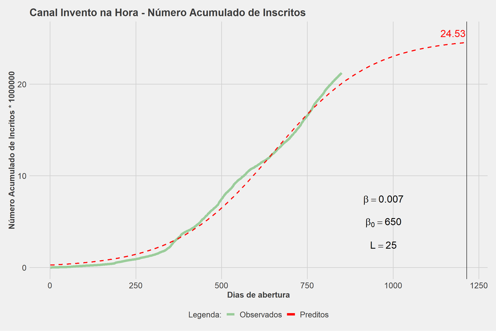

```r
par.adj.c1 <- c(0.007, 650, 25)
df.1.pred$adj <- f.log(par = par.adj.c1, dias = df.1.pred$DIAS)

cum.plot.pred <- function(df, x, y1, y2, title, params) {
  ggplot(df, aes(x)) +
    geom_line(aes(y = y1, color = "Observados"), size = 2) +
    geom_line(aes(y = y2, color = "Preditos"), linetype = "dashed", size = 1) +
    scale_color_manual(name = "Legenda:", values = c("Preditos" = "red", "Observados" = "darkseagreen3")) +
    labs(x = "Dias de abertura", y = "Número Acumulado de Incritos * 1000000", title = title) +
    geom_vline(xintercept = max(x), linetype = "solid", color = "black") +
    annotate("text", x = max(x)-40, y = max(y2)+1, label = round(max(y2),2), size = 6, color = "red") +
    annotate("text", x = max(x)*0.8, y = max(y2)*0.1, label = paste0("L==",params[3]), size = 6, parse = T) +
    annotate("text", x = max(x)*0.8, y = max(y2)*0.2, label = paste0("beta[0]==",params[2]), size = 6, parse = T) +
    annotate("text", x = max(x)*0.8, y = max(y2)*0.3, label = paste0("beta==",params[1]), size = 6, parse = T) +
    theme_fivethirtyeight() +
    theme(axis.text = element_text(size = 14),
          axis.title = element_text(size = 14, face = "bold"),
          plot.title = element_text(size = 18),
          legend.title = element_text(size = 14),
          legend.text = element_text(size = 14))
}

cum.plot.pred(df = df.1.pred, x = df.1.pred$DIAS, y1 = df.1.pred$cum.inscritos, y2 = df.1.pred$adj, title = paste(title.c1, "Número Acumulado de Inscritos", sep = " - "), params = par.adj.c1)
```

#### 5.6 - Otimizando o modelo:

##### 5.6.1 - Criando um grid de combinações em torno dos parâmetros encontrados manualmente no tópico anterior para serem testados:

```r
init.beta <- seq(0.006, 0.009, 0.001)
init.beta0 <- seq(600, 700, 1)
init.L <- seq(20, 40, 1)

grid.c1 <- as.data.frame(crossing(init.beta, init.beta0, init.L))

head(grid.c1)
```

```
##   init.beta init.beta0 init.L
## 1     0.006        600     20
## 2     0.006        600     21
## 3     0.006        600     22
## 4     0.006        600     23
## 5     0.006        600     24
## 6     0.006        600     25
```

##### 5.6.2 - Executando o otimizador com cada uma das combinações do grid como parâmetros iniciais:

```r
grid.c1$fit.beta <- NA
grid.c1$fit.beta0 <- NA
grid.c1$fit.L <- NA
for(i in 1:nrow(grid.c1)) {
  fit <- optim(par = c(grid.c1$init.beta[i], grid.c1$init.beta0[i], grid.c1$init.L[i]), fn = f.log.ols, dias = df.1$DIAS, y = df.1$cum.inscritos)$par
  grid.c1$fit.beta[i] <- fit[1]
  grid.c1$fit.beta0[i] <- fit[2]
  grid.c1$fit.L[i] <- fit[3]
}

head(grid.c1)
```

```
##   init.beta init.beta0 init.L    fit.beta fit.beta0    fit.L
## 1     0.006        600     20 0.007328446  630.2338 24.20081
## 2     0.006        600     21 0.008474650  584.5578 20.99438
## 3     0.006        600     22 0.007327629  630.2610 24.20304
## 4     0.006        600     23 0.007694614  613.4092 22.99563
## 5     0.006        600     24 0.007385492  627.4463 23.99891
## 6     0.006        600     25 0.007119217  641.0966 24.99826
```

##### 5.6.3 - Encontrando perda quadrática para cada uma das combinações testadas e selecionando a menor:

```r
grid.c1$SQ <- NA
for(i in 1:nrow(grid.c1)) {
  perda <- f.log.ols(par = c(grid.c1$fit.beta[i], grid.c1$fit.beta0[i], grid.c1$fit.L[i]), y = df.1$cum.inscritos, dias = df.1$DIAS)
  grid.c1$SQ[i] <- perda
}

min.loss.c1 <- grid.c1[grid.c1$SQ == min(grid.c1$SQ),]
min.loss.c1
```

```
##      init.beta init.beta0 init.L    fit.beta fit.beta0    fit.L       SQ
## 4877     0.008        630     24 0.007327984  630.2566 24.20271 247.1548
```

##### 5.6.4 - Populando o data frame e plotando os valores preditos:

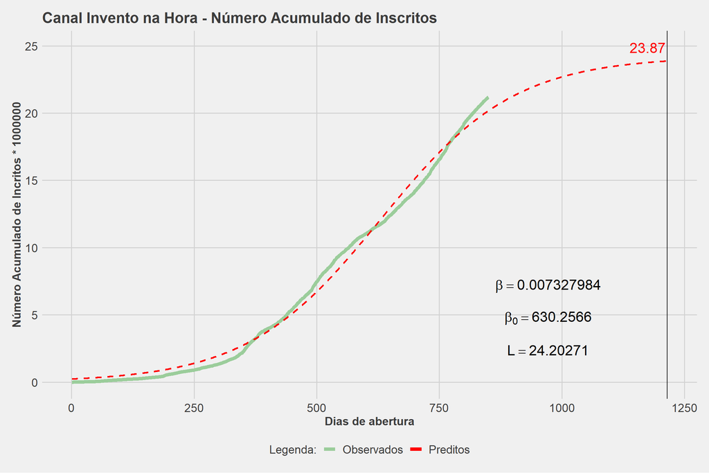

```r
par.optim.c1 <- c(min.loss.c1$fit.beta, min.loss.c1$fit.beta0, min.loss.c1$fit.L)
df.1.pred$fit <- f.log(par = par.optim.c1, dias = df.1.pred$DIAS)

cum.plot.pred(df = df.1.pred, x = df.1.pred$DIAS, y1 = df.1.pred$cum.inscritos, y2 = df.1.pred$fit, title = paste(title.c1, "Número Acumulado de Inscritos", sep = " - "), params = par.optim.c1)
```

### 6 - Canal 2 - Você Sabia:

#### 6.1 - Sumarizando os dados:

```r
summary(df.2)
```

```
##       DIAS           VIEWS          INSCRITOS        CANAL
##  Min.   :  1.0   Min.   :    89   Min.   :    1   Length:607
##  1st Qu.:152.5   1st Qu.: 18626   1st Qu.:  739   Class :character
##  Median :304.0   Median : 89125   Median : 1760   Mode  :character
##  Mean   :304.0   Mean   :169616   Mean   : 2514
##  3rd Qu.:455.5   3rd Qu.:292977   3rd Qu.: 4098
##  Max.   :607.0   Max.   :934121   Max.   :14005
##  cum.inscritos
##  Min.   : 0.00315
##  1st Qu.: 0.82123
##  Median : 2.92724
##  Mean   : 4.28537
##  3rd Qu.: 6.39842
##  Max.   :15.26248
```

#### 6.2 - Plotando o número acumulado de inscritos por dia:

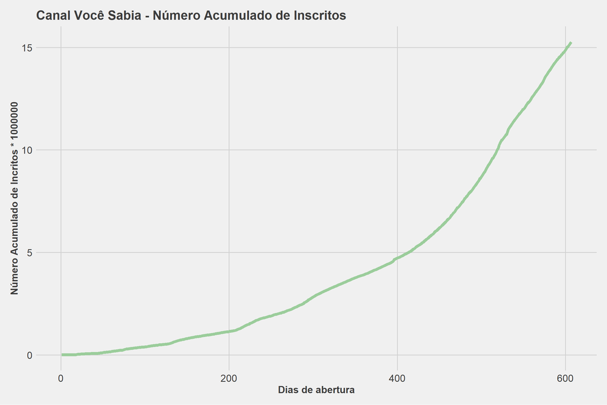

```r
title.c2 = "Canal Você Sabia"

cum.plot(df = df.2, x = df.2$DIAS, y = df.2$cum.inscritos, title = paste(title.c2, "Número Acumulado de Inscritos", sep = " - "))
```

#### 6.3 - Plotando o número de inscritos por dia:

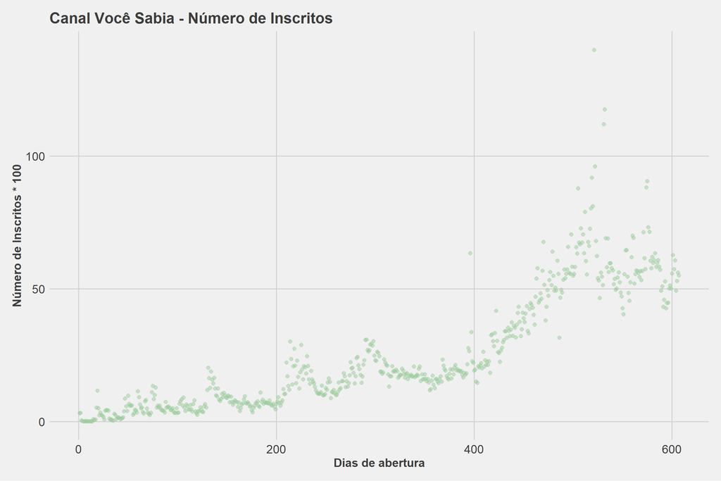

```r
qty.plot(df = df.2, x = df.2$DIAS, y = df.2$INSCRITOS, title = paste(title.c2, "Número de Inscritos", sep = " - "))
```

#### 6.4 - Preparando um data frame com o número total de dias:

```r
df.2.pred <- pred.df(df.2, 365)
```

#### 6.5 - Variando manualmente os parâmetros até encontrar os valores mais próximos do ótimo:

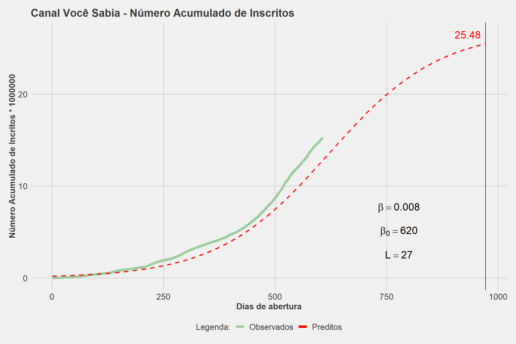

```r
par.adj.c2 <- c(0.008, 620, 27)
df.2.pred$adj <- f.log(par = par.adj.c2, dias = df.2.pred$DIAS)

cum.plot.pred(df = df.2.pred, x = df.2.pred$DIAS, y1 = df.2.pred$cum.inscritos, y2 = df.2.pred$adj, title = paste(title.c2, "Número Acumulado de Inscritos", sep = " - "), params = par.adj.c2)
```

#### 6.6 - Otimizando o modelo:

##### 6.6.1 - Criando um grid de combinações em torno dos parâmetros encontrados manualmente no tópico anterior para serem testados:

```r
init.beta <- seq(0.007, 0.01, 0.001)
init.beta0 <- seq(550, 750, 1)
init.L <- seq(25, 50, 1)

grid.c2 <- as.data.frame(crossing(init.beta, init.beta0, init.L))

head(grid.c2)
```

```
##   init.beta init.beta0 init.L
## 1     0.007        550     25
## 2     0.007        550     26
## 3     0.007        550     27
## 4     0.007        550     28
## 5     0.007        550     29
## 6     0.007        550     30
```

##### 6.6.2 - Executando o otimizador com cada uma das combinações do grid como parâmetros iniciais:

```r
grid.c2$fit.beta <- NA
grid.c2$fit.beta0 <- NA
grid.c2$fit.L <- NA
for(i in 1:nrow(grid.c2)) {
  fit <- optim(par = c(grid.c2$init.beta[i], grid.c2$init.beta0[i], grid.c2$init.L[i]), fn = f.log.ols, dias = df.2$DIAS, y = df.2$cum.inscritos)$par
  grid.c2$fit.beta[i] <- fit[1]
  grid.c2$fit.beta0[i] <- fit[2]
  grid.c2$fit.L[i] <- fit[3]
}

head(grid.c1)
```

```
##   init.beta init.beta0 init.L    fit.beta fit.beta0    fit.L       SQ
## 1     0.006        600     20 0.007328446  630.2338 24.20081 247.1548
## 2     0.006        600     21 0.008474650  584.5578 20.99438 334.1124
## 3     0.006        600     22 0.007327629  630.2610 24.20304 247.1548
## 4     0.006        600     23 0.007694614  613.4092 22.99563 256.2728
## 5     0.006        600     24 0.007385492  627.4463 23.99891 247.3813
## 6     0.006        600     25 0.007119217  641.0966 24.99826 250.1799
```

##### 6.6.3 - Encontrando perda quadrática para cada uma das combinações testadas e selecionando a menor:

```r
grid.c2$SQ <- NA
for(i in 1:nrow(grid.c2)) {
  perda <- f.log.ols(par = c(grid.c2$fit.beta[i], grid.c2$fit.beta0[i], grid.c2$fit.L[i]), y = df.2$cum.inscritos, dias = df.2$DIAS)
  grid.c2$SQ[i] <- perda
}

min.loss.c2 <- grid.c2[grid.c2$SQ == min(grid.c2$SQ),]
min.loss.c2
```

```
##       init.beta init.beta0 init.L    fit.beta fit.beta0    fit.L       SQ
## 10713     0.009        560     25 0.007184503  702.2269 46.69809 35.76566
```

##### 6.6.4 - Populando o data frame e plotando os valores preditos:

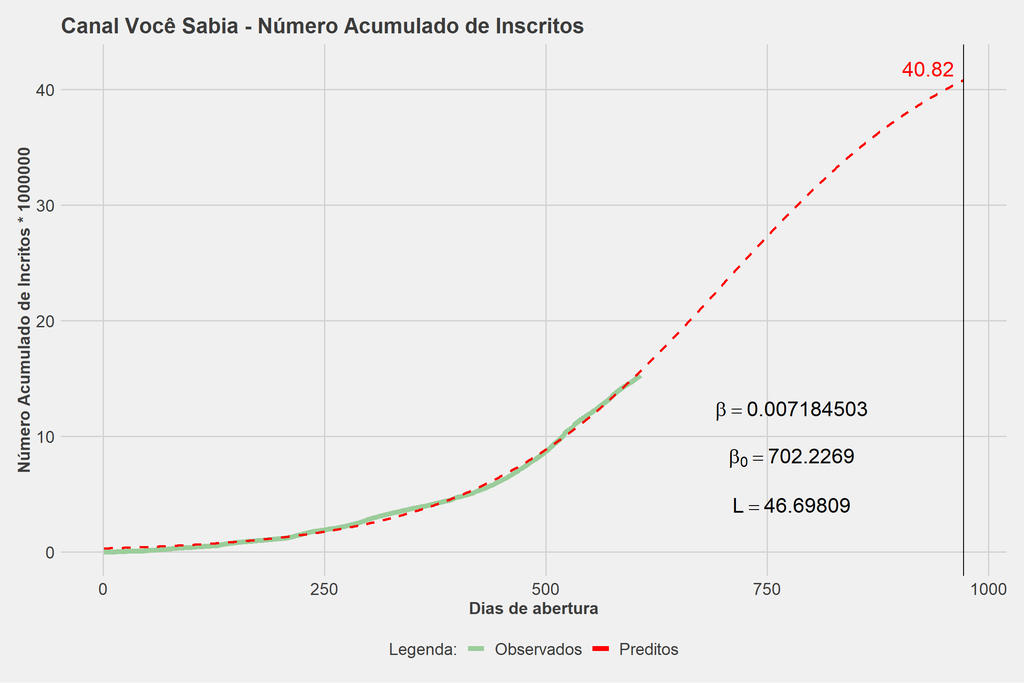

```r
par.optim.c2 <- c(min.loss.c2$fit.beta, min.loss.c2$fit.beta0, min.loss.c2$fit.L)
df.2.pred$fit <- f.log(par = par.optim.c2, dias = df.2.pred$DIAS)

cum.plot.pred(df = df.2.pred, x = df.2.pred$DIAS, y1 = df.2.pred$cum.inscritos, y2 = df.2.pred$fit, title = paste(title.c2, "Número Acumulado de Inscritos", sep = " - "), params = par.optim.c2)
```

#### 7 - Resumindo as informações:

```r
df.resumo <- data.frame(
  canal = c(as.character(channels[1]), as.character(channels[2])),
  inscritos.atual = c(max(df.1$cum.inscritos)*100000, max(df.2$cum.inscritos)*100000),
  inscritos.365 = c(round(max(df.1.pred$fit)*100000,0), round(max(df.2.pred$fit)*100000,0))
)
df.resumo$crescimento = df.resumo$inscritos.365 - df.resumo$inscritos.atual
df.resumo$cresc.perc = paste(round(df.resumo$crescimento / df.resumo$inscritos.atual * 100, 1), "%")

df.resumo
```

```
##           canal inscritos.atual inscritos.365 crescimento cresc.perc
## 1 inventonahora         2120289       2387388      267099     12.6 %
## 2     vocesabia         1526248       4082126     2555878    167.5 %
```

### 7 - Conclusão:

Antes de utilizar o otimizador, foram realizados alguns testes com os parâmtros $\beta$, $\beta_0$ e $L$, variando manualmente a combinação deles e observando o comportamento da curva, para encontrar bons valores iniciais. Foi passada para o otimizador, como parâmetros iniciais, uma combinação que resultou em um comportamento semelhante ao da curva do número acumulado de inscritos. No entanto, foi observado que ao alterar, mesmo que sutilmente, os parâmetros iniciais, o otimizador apresentava resultados diferentes, então foi criado um grid de parâmetros, passada todas as combinações possíveis para o otimizador, armazenado os resultados em um data frame e calculada a perda quadrática em cada caso. Em seguida foi identificada a combinação dos parâmetros que resultou na menor perda quadrática e considerada esta combinação para realizar a predição.

De acordo com o modelo ajustado abaixo, em 365 dias o canal *Invento na Hora* terá obtido mais **267.099** inscritos, totalizando **2.387.388**, apresentando um crescimento de **12,6 %**.

$$y = \dfrac{24.20271}{1 + e^{-0.007327984(x - 630.2566)}}$$
E de acordo com o modelo ajustado abaixo, em 365 dias o canal *Você Sabia* terá obtido mais **2.555.878** inscritos, totalizando **4.082.126**, apresentando um crescimento de **167,5 %**.

$$y = \dfrac{46.69809}{1 + e^{-0.007184503(x - 702.2269)}}$$